# Analysis of 450k data using minfi

Jean-Philippe Fortin, Peter Hickey, Kasper Daniel Hansen

# 1 Introduction

The goal of this tutorial is to present a standard analysis workflow of 450K data with the package *minfi*, incorporating the functions recently added to the package. We invite you to read the software paper (Martin J Aryee et al. 2014) and the online package vignette on the Bioconductor project website for more details.

We will start from the very beginning by reading input raw data (IDAT files) from an example dataset, and ending with a list of candidate genes for differential methylation. Among others, we will cover quality control assessments, different within-array and between-array normalizations, SNPs removal, sex prediction, differentially methylated positions (DMPs) analysis and bump hunting for differentially methylated regions (DMRs).

If time permits, we will introduce a complementary interactive visualization tool package available through Bioconductor, *shinyMethyl*, that allows interactive quality control assessment.

## 1.1 Dependencies

```r
library(minfi)
library(minfiData)
library(sva)
library(Gviz)
library(FlowSorted.Blood.450k)
library(shinyMethyl)
library(shinyMethylData)
library(tutorial.450k)
```

These dependencies can be installed from Bioconductor.

**NOTE:** No need to run this chunk if you’re in the workshop at BioC 2016 and using the Amazon Machine Image

```r
# WARNING: No need to run this chunk if you're in the workshop at BioC 2016 and
#          using the Amazon Machine Image
source("http://www.bioconductor.org/biocLite.R")
useDevel(TRUE)
# NOTE: You may not need `type = "source"`
biocLite(c("minfi", "minfiData", "sva", "Gviz", "FlowSorted.Blood.450k",
           "shinyMethyl", "shinyMethylData"),
         type = "source")
```

Note that we are using the **devel** branch of Bioconductor in this vignette (`v3.4` at time of writing).

This tutorial can be installed from GitHub using *[devtools](http://cran.fhcrc.org/web/packages/devtools/index.html)* by

```r
# NOTE: You'll also need the devtools package to install the tutorial from
#       GitHub
biocLite("devtools")
biocLite("hansenlab/tutorial.450k")
```

## 1.2 450k array design and terminology

In this section, we briefly introduce the 450K array as well as the terminology used throughout the *minfi* package. Each sample is measured on a single array, in two different color channels (red and green). As the name of the platform indicates, each array measures more than 450,000 CpG positions. For each CpG, we have two measurements: a methylated intensity and an unmethylated intensity. Depending on the probe design, the signals are reported in different colors:

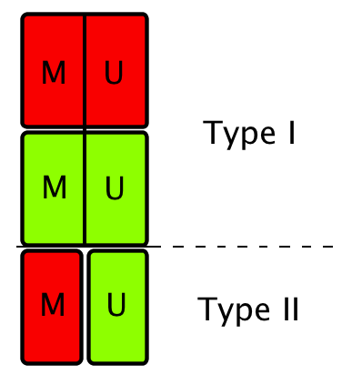

Two commonly measures are used to report the methylation levels: Beta values and M values.

**Beta value**:
$$\frac{M}{M + U + 100}$$

where $M$ and $U$ denote the methylated and unmethylated signals respectively.

**MValue**:
$$\log{\biggl(\frac{M}{U}\biggr)}$$

**DMP**: Differentially methylated position: single genomic position that has a different methylated level in two different groups of samples (or conditions)

**DMR**: Differentially methylated region: when consecutive genomic locations are differentially methylated in the same direction.

**Array**: One sample

**Slide**: Physical slide containing 12 arrays ($6 \times 2$ grid)

**Plate** Physical plate containing at most 8 slides (96 arrays). For this tutorial, we use **batch** and plate interchangeably.

## 1.3 Other Illumina methylation arrays

As of Bioconductor 3.3, *minfi* supports the Illumina EPIC methylation array (also known as the 850k), the successor to the 450k array, and has partial supports for the older 27k array.

The 27k array uses the *Type I* design for all probes. The EPIC array, like the 450k array, uses a combination of *Type I* and *Type II* probes. Some additional details about the EPIC array:

- Each slide contains 8 arrays ($8 \times 1$ grid)
- Includes more CpG sites outside of CpG islands
- Includes non-CpG methylated sites identified in human stem cells (CHH sites)
- Includes differentially methylated sites identified in tumor versus normal
- Targets FANTOM5 enhancers
- Targets ENCODE open chromatin and enhancers
- Targets DNase hypersensitive sites
- Targets miRNA promoter regions
- $> 90\%$ of content contained on the 450k array

# 2 Reading Data

The starting point of *minfi* is reading the .IDAT files with the built-in function `read.metharray.exp`[^1]. Several options are available: the user can specify the sample filenames to be read in along with the directory path, or can specify the directory that contains the files. In the latter case, all the files with the extension .IDAT located in the directory will be loaded into R. The user can also read in a sample sheet, and then use the sample sheet to load the data into a `RGChannelSet`. For more information, see the *minfi* vignette. Here, we will load the dataset containing 6 samples from the *minfiData* package using the sample sheet provided within the package:

```r
baseDir <- system.file("extdata", package="minfiData")
targets <- read.metharray.sheet(baseDir)
```

```
## [read.metharray.sheet] Found the following CSV files:
```

```
## [1] "/Library/Frameworks/R.framework/Versions/3.3/Resources/library/minfiData/extdata/SampleSheet.csv"
```

```r
targets
```

```
##   Sample_Name Sample_Well Sample_Plate Sample_Group Pool_ID person age sex
## 1    GroupA_3          H5           NA       GroupA      NA    id3  83   M
## 2    GroupA_2          D5           NA       GroupA      NA    id2  58   F
## 3    GroupB_3          C6           NA       GroupB      NA    id3  83   M
## 4    GroupB_1          F7           NA       GroupB      NA    id1  75   F
## 5    GroupA_1          G7           NA       GroupA      NA    id1  75   F
## 6    GroupB_2          H7           NA       GroupB      NA    id2  58   F
##   status  Array      Slide
## 1 normal R02C02 5723646052
## 2 normal R04C01 5723646052
## 3 cancer R05C02 5723646052
## 4 cancer R04C02 5723646053
## 5 normal R05C02 5723646053
## 6 cancer R06C02 5723646053
##                                                                                                        Basename
## 1 /Library/Frameworks/R.framework/Versions/3.3/Resources/library/minfiData/extdata/5723646052/5723646052_R02C02
## 2 /Library/Frameworks/R.framework/Versions/3.3/Resources/library/minfiData/extdata/5723646052/5723646052_R04C01
## 3 /Library/Frameworks/R.framework/Versions/3.3/Resources/library/minfiData/extdata/5723646052/5723646052_R05C02
## 4 /Library/Frameworks/R.framework/Versions/3.3/Resources/library/minfiData/extdata/5723646053/5723646053_R04C02
## 5 /Library/Frameworks/R.framework/Versions/3.3/Resources/library/minfiData/extdata/5723646053/5723646053_R05C02
## 6 /Library/Frameworks/R.framework/Versions/3.3/Resources/library/minfiData/extdata/5723646053/5723646053_R06C02
```

```r
RGSet <- read.metharray.exp(targets = targets)
```

The class of RGSet is a `RGChannelSet` object. This is the initial object of a minfi analysis that contains the raw intensities in the green and red channels. Note that this object contains the intensities of the internal control probes as well. Because we read the data from a data sheet experiment, the phenotype data is also stored in the `RGChannelSet` and can be accessed via the accessor command `pData`:

```r
phenoData <- pData(RGSet)
phenoData[,1:6]
```

```
##                   Sample_Name Sample_Well Sample_Plate Sample_Group
## 5723646052_R02C02    GroupA_3          H5           NA       GroupA
## 5723646052_R04C01    GroupA_2          D5           NA       GroupA
## 5723646052_R05C02    GroupB_3          C6           NA       GroupB
## 5723646053_R04C02    GroupB_1          F7           NA       GroupB
## 5723646053_R05C02    GroupA_1          G7           NA       GroupA
## 5723646053_R06C02    GroupB_2          H7           NA       GroupB
##                   Pool_ID person
## 5723646052_R02C02      NA    id3
## 5723646052_R04C01      NA    id2
## 5723646052_R05C02      NA    id3
## 5723646053_R04C02      NA    id1
## 5723646053_R05C02      NA    id1
## 5723646053_R06C02      NA    id2
```

The `RGChannelSet` stores also a manifest object that contains the probe design information of the array:

```r
manifest <- getManifest(RGSet)
manifest
```

```
## IlluminaMethylationManifest object
## Annotation
##   array: IlluminaHumanMethylation450k
## Number of type I probes: 135476
## Number of type II probes: 350036
## Number of control probes: 850
## Number of SNP type I probes: 25
## Number of SNP type II probes: 40
```

```r
head(getProbeInfo(manifest))
```

```
## DataFrame with 6 rows and 8 columns
##          Name    AddressA    AddressB       Color       NextBase
##   <character> <character> <character> <character> <DNAStringSet>
## 1  cg00050873    32735311    31717405         Red              A
## 2  cg00212031    29674443    38703326         Red              T
## 3  cg00213748    30703409    36767301         Red              A
## 4  cg00214611    69792329    46723459         Red              A
## 5  cg00455876    27653438    69732350         Red              A
## 6  cg01707559    45652402    64689504         Red              A
##                 ProbeSeqA               ProbeSeqB      nCpG
##            <DNAStringSet>          <DNAStringSet> <integer>
## 1 ACAAAAAAAC...ATAAACCCCA ACGAAAAAAC...ATAAACCCCG         2
## 2 CCCAATTAAC...AAAACATACA CCCAATTAAC...AAAACGTACG         4
## 3 TTTTAACACC...AAAAAAAACA TTTTAACGCC...AAAAAAAACG         3
## 4 CTAACTTCCA...AACACAAACA CTAACTTCCG...AACGCGAACG         5
## 5 AACTCTAAAC...AAAAAACTCA AACTCTAAAC...AAAAAACTCG         2
## 6 ACAAATTAAA...ACAAAAAACA GCGAATTAAA...ACAAAAAACG         6
```

See the [minfi vignette](http://bioconductor.org/packages/devel/bioc/vignettes/minfi/inst/doc/minfi.pdf) for more information.

# 3 Classes

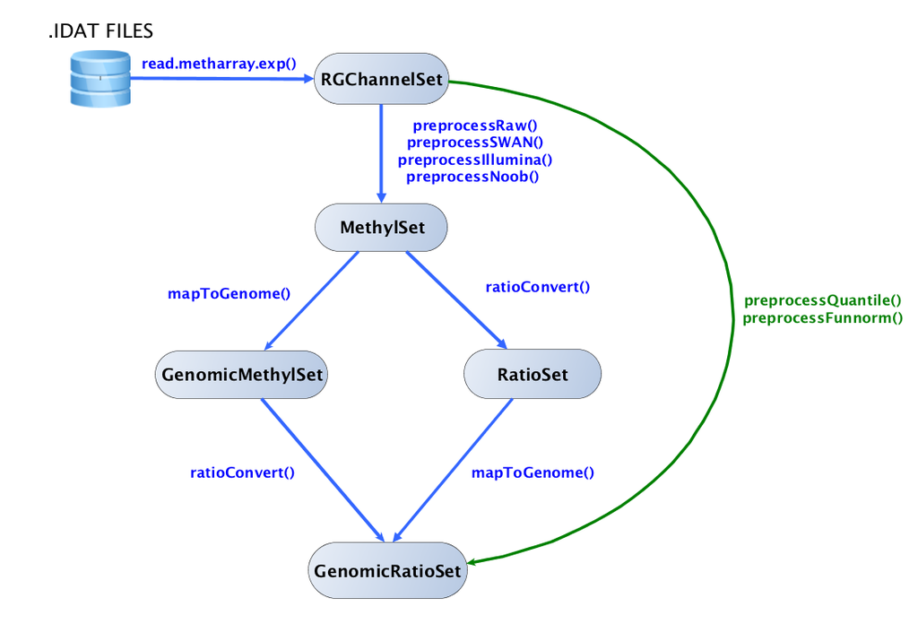

## 3.1 MethylSet and RatioSet

A `MethylSet` objects contains only the methylated and unmethylated signals. You create this by

```r
MSet <- preprocessRaw(RGSet)
MSet
```

```
## MethylSet (storageMode: lockedEnvironment)
## assayData: 485512 features, 6 samples
##   element names: Meth, Unmeth
## An object of class 'AnnotatedDataFrame'
##   sampleNames: 5723646052_R02C02 5723646052_R04C01 ...
##     5723646053_R06C02 (6 total)
##   varLabels: Sample_Name Sample_Well ... filenames (13 total)
##   varMetadata: labelDescription
## Annotation
##   array: IlluminaHumanMethylation450k
##   annotation: ilmn12.hg19
## Preprocessing
##   Method: Raw (no normalization or bg correction)
##   minfi version: 1.19.2
##   Manifest version: 0.4.0
```

`preprocessRaw` matches up the different probes and color channels. Note that the dimension of this object is much smaller than for the `RGChannelSet`; this is because CpGs measured by type I probes are measured by 2 probes.

The accessors `getMeth` and `getUnmeth` can be used to get the methylated and unmethylated intensities matrices:

```r
head(getMeth(MSet)[,1:3])
```

```
##            5723646052_R02C02 5723646052_R04C01 5723646052_R05C02
## cg00050873             22041               588             20505
## cg00212031               679               569               439
## cg00213748              1620               421               707
## cg00214611               449               614               343
## cg00455876              5921               398              3257
## cg01707559              1238               646               637
```

```r
head(getUnmeth(MSet)[,1:3])
```

```
##            5723646052_R02C02 5723646052_R04C01 5723646052_R05C02
## cg00050873              1945               433              1012
## cg00212031              6567               300              2689
## cg00213748               384               461               295
## cg00214611              4869               183              1655
## cg00455876              1655               792              1060
## cg01707559             12227              1009              7414
```

Other preprocessing functions exists; see below for an extensive discussion.

A `RatioSet` object is a class designed to store Beta values and/or M values instead of the methylated and unmethylated signals. An optional copy number matrix, `CN`, the sum of the methylated and unmethylated signals, can be also stored. Mapping a `MethylSet` to a `RatioSet` may be irreversible, i.e. one cannot be guaranteed to retrieve the methylated and unmethylated signals from a `RatioSet`. A `RatioSet` can be created with the function `ratioConvert`:

```r
RSet <- ratioConvert(MSet, what = "both", keepCN = TRUE)
RSet
```

```
## RatioSet (storageMode: lockedEnvironment)
## assayData: 485512 features, 6 samples
##   element names: Beta, CN, M
## An object of class 'AnnotatedDataFrame'
##   sampleNames: 5723646052_R02C02 5723646052_R04C01 ...
##     5723646053_R06C02 (6 total)
##   varLabels: Sample_Name Sample_Well ... filenames (13 total)
##   varMetadata: labelDescription
## Annotation
##   array: IlluminaHumanMethylation450k
##   annotation: ilmn12.hg19
## Preprocessing
##   Method: Raw (no normalization or bg correction)
##   minfi version: 1.19.2
##   Manifest version: 0.4.0
```

The functions `getBeta`, `getM` and `getCN` return respectively the Beta value matrix, M value matrix and the Copy Number matrix.

```r
beta <- getBeta(RSet)
```

## 3.2 GenomicRatioSet

The function `mapToGenome` applied to a `RatioSet` object will add genomic coordinates to each probe together with some additional annotation information. The output object is a `GenomicRatioSet` (class holding M or/and Beta values together with associated genomic coordinates). It is possible to merge the manifest object with the genomic locations by setting the option `mergeManifest` to `TRUE`.

```r
GRset <- mapToGenome(RSet)
GRset
```

```
## class: GenomicRatioSet
## dim: 485512 6
## metadata(0):
## assays(3): Beta M CN
## rownames(485512): cg13869341 cg14008030 ... cg08265308 cg14273923
## rowData names(0):
## colnames(6): 5723646052_R02C02 5723646052_R04C01 ...
##   5723646053_R05C02 5723646053_R06C02
## colData names(13): Sample_Name Sample_Well ... Basename filenames
## Annotation
##   array: IlluminaHumanMethylation450k
##   annotation: ilmn12.hg19
## Preprocessing
##   Method: Raw (no normalization or bg correction)
##   minfi version: 1.19.2
##   Manifest version: 0.4.0
```

Note that the `GenomicRatioSet` extends the class `SummarizedExperiment`. Here are the main accessors functions to access the data:

```r
beta <- getBeta(GRset)
M <- getM(GRset)
CN <- getCN(GRset)
```

```r
sampleNames <- sampleNames(GRset)
probeNames <- featureNames(GRset)
pheno <- pData(GRset)
```

To return the probe locations as a `GRanges` objects, one can use the accessor `granges`:

```r
gr <- granges(GRset)
head(gr, n = 3)
```

```
## GRanges object with 3 ranges and 0 metadata columns:
##              seqnames         ranges strand
##                 <Rle>      <IRanges>  <Rle>
##   cg13869341     chr1 [15865, 15865]      *
##   cg14008030     chr1 [18827, 18827]      *
##   cg12045430     chr1 [29407, 29407]      *
##   -------
##   seqinfo: 24 sequences from hg19 genome; no seqlengths
```

To access the full annotation, one can use the command `getAnnotation`:

```r
annotation <- getAnnotation(GRset)
names(annotation)
```

```
##  [1] "chr"                      "pos"
##  [3] "strand"                   "Name"
##  [5] "AddressA"                 "AddressB"
##  [7] "ProbeSeqA"                "ProbeSeqB"
##  [9] "Type"                     "NextBase"
## [11] "Color"                    "Probe_rs"
## [13] "Probe_maf"                "CpG_rs"
## [15] "CpG_maf"                  "SBE_rs"
## [17] "SBE_maf"                  "Islands_Name"
## [19] "Relation_to_Island"       "Forward_Sequence"
## [21] "SourceSeq"                "Random_Loci"
## [23] "Methyl27_Loci"            "UCSC_RefGene_Name"
## [25] "UCSC_RefGene_Accession"   "UCSC_RefGene_Group"
## [27] "Phantom"                  "DMR"
## [29] "Enhancer"                 "HMM_Island"
## [31] "Regulatory_Feature_Name"  "Regulatory_Feature_Group"
## [33] "DHS"
```

## 3.3 GenomicMethylSet

The `mapToGenome` function can also be used on `MethylSet` to get a `GenomicMethylSet`. The `ratioConvert` and `mapToGenome` functions commute, see the diagram above.

# 4 Quality control

## 4.1 QC plot

*minfi* provides a simple quality control plot that uses the log median intensity in both the methylated (M) and unmethylated (U) channels. When plotting these two medians against each other, it has been observed that good samples cluster together, while failed samples tend to separate and have lower median intensities. In order to obtain the methylated and unmethylated signals, we need to convert the `RGChannelSet` to an object containing the methylated and unmethylated signals using the function `preprocessRaw`. As we’ve already seen, it takes as input a `RGChannelSet` and converts the red and green intensities to methylated and unmethylated signals according to the probe design of the array, and returns the converted signals in a new object of class `MethylSet`. It does not perform any normalization.

The accessors `getMeth` and `getUnmeth` can be used to get the methylated and unmethylated intensities matrices:

```r
head(getMeth(MSet)[,1:3])
```

```
##            5723646052_R02C02 5723646052_R04C01 5723646052_R05C02
## cg00050873             22041               588             20505
## cg00212031               679               569               439
## cg00213748              1620               421               707
## cg00214611               449               614               343
## cg00455876              5921               398              3257
## cg01707559              1238               646               637
```

```r
head(getUnmeth(MSet)[,1:3])
```

```
##            5723646052_R02C02 5723646052_R04C01 5723646052_R05C02
## cg00050873              1945               433              1012
## cg00212031              6567               300              2689
## cg00213748               384               461               295
## cg00214611              4869               183              1655
## cg00455876              1655               792              1060
## cg01707559             12227              1009              7414
```

The functions `getQC` and `plotQC` are designed to extract and plot the quality control information from the `MethylSet`:

```r
qc <- getQC(MSet)
qc
```

```
## DataFrame with 6 rows and 2 columns
##                        mMed      uMed
##                   <numeric> <numeric>
## 5723646052_R02C02  11.69566  11.82058
## 5723646052_R04C01  11.99046  11.95274
## 5723646052_R05C02  11.55603  12.05393
## 5723646053_R04C02  12.06609  12.09276
## 5723646053_R05C02  12.23332  12.08448
## 5723646053_R06C02  11.36851  11.60594
```

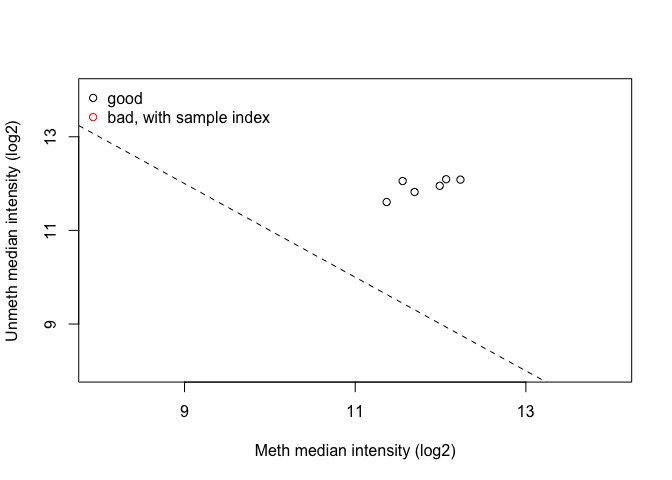

```r
plotQC(qc)
```

Moreover, the function `addQC` applied to the `MethylSet` will add the QC information to the phenotype data.

To further explore the quality of the samples, it is useful to look at the Beta value densities of the samples, with the option to color the densities by group:

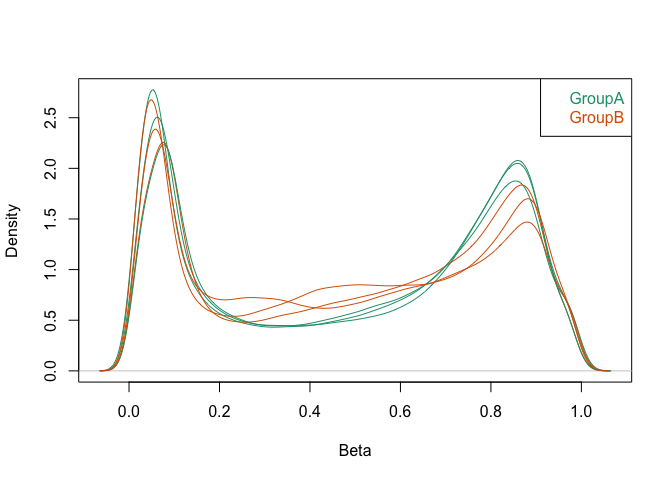

```r
densityPlot(MSet, sampGroups = phenoData$Sample_Group)
```

or density bean plots:

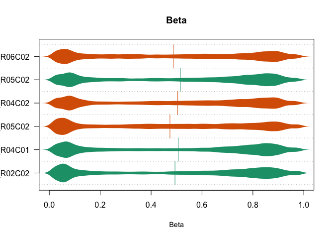

```r
densityBeanPlot(MSet, sampGroups = phenoData$Sample_Group)
```

*shinyMethyl* is particularly useful to visualize all plots at the same time in an interactive fashion.

## 4.2 Control probes plot

The 450k array contains several internal control probes that can be used to assess the quality control of different sample preparation steps (bisulfite conversion, hybridization, etc.). The values of these control probes are stored in the initial `RGChannelSet` and can be plotted by using the function `controlStripPlot` and by specifying the control probe type:

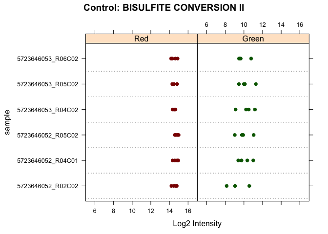

```r
controlStripPlot(RGSet, controls="BISULFITE CONVERSION II")
```

All the plots above can be exported into a pdf file in one step using the function `qcReport`:

```r
qcReport(RGSet,
         sampNames = phenoData(RGSet)$Sample_Name,
         sampGroups = phenoData(RGSet)$Sample_Group,
         pdf= "qcReport.pdf")
```

## 4.3 Sex prediction

By looking at the median total intensity of the X chromosome-mapped probes, denoted $med(X)$, and the median total intensity of the Y-chromosome-mapped probes, denoted $med(Y)$, one can observe two different clusters of points corresponding to which sex the samples belong to. To predict the sex, minfi separates the points by using a cutoff on $\log_2{med(Y)}-\log_2{med(Y)}$. The default cutoff is $-2$. Since the algorithm needs to map probes to the X-chr and to the Y-chr, the input of the function `getSex` needs to be a `GenomicMethylSet` or a `GenomicRatioSet`.

```r
predictedSex <- getSex(GRset, cutoff = -2)$predictedSex
predictedSex
```

```
## [1] "M" "F" "M" "F" "F" "F"
```

To choose the cutoff to separate the two sex clusters, one can plot $med(Y)$ against $med(X)$ with the function `plotSex`:

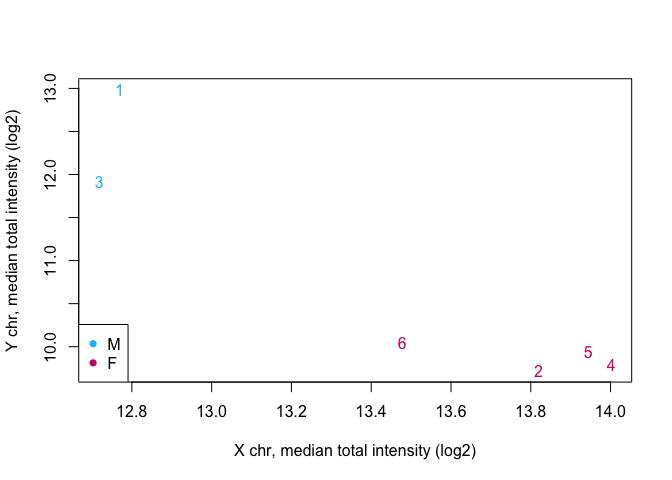

```r
plotSex(getSex(GRset, cutoff = -2))
```

Finally, the function `addSex` applied to the `GenomicRatioSet` will add the predicted sex to the phenotype data.

**Note**: `getSex` does not handle datasets with only females or only males and the results will need more careful interpretation in the presence of sex chromosome aneuploidies.

# 5 Preprocessing and normalization

So far, we did not use any normalization to process the data. Different normalization procedures are available in *minfi*. Many people have asked us which normalization they should apply to their dataset. Our rule of thumb is the following. If there exist global biological methylation differences between your samples, as for instance a dataset with cancer and normal samples, or a dataset with different tissues/cell types, use the `preprocessFunnorm` function as it is designed for such datasets. On the other hand, if you do not expect global differences between your samples, for instance a blood dataset, or one-tissue dataset, use the `preprocessQuantile` function. In our experience, these two normalization procedures perform always better than the functions `preprocessRaw`, `preprocessIllumina` and `preprocessSWAN` discussed below. For convenience, these functions are still implemented in the minfi package, as is `preprocessNoob`.

## 5.1 preprocessRaw

As we’ve already seen, `preprocessRaw` converts a `RGChannelSet` to a `MethylSet` by converting the Red and Green channels into a matrix of methylated signals and a matrix of unmethylated signals. **No normalization is performed.**

Input: `RGChannelSet`  
Output: `MethylSet`

## 5.2 preprocessIllumina

Convert a `RGChannelSet` to a `MethylSet` by implementing the preprocessing choices as available in Illumina’s Genome Studio software: background subtraction and control normalization. Each of these is optional, and turning them off is equivalent to raw preprocessing (`preprocessRaw`):

```r
MSet.illumina <- preprocessIllumina(RGSet, bg.correct = TRUE,
                                    normalize = "controls")
```

Input: `RGChannelSet`  
Output: `MethylSet`

## 5.3 preprocessSWAN

Perform **s**ubset-quantile **w**ithin **a**rray **n**ormalization (SWAN) (Jovana Maksimovic, Lavinia Gordon, and Alicia Oshlack 2012), a within-array normalization correction for the technical differences between the Type I and Type II array designs. The algorithm matches the Beta-value distributions of the Type I and Type II probes by applying a within-array quantile normalization separately for different subsets of probes (divided by CpG content). The input of SWAN is a `MethylSet`, and the function returns a `MethylSet` as well. If an `RGChannelSet` is provided instead, the function will first call `preprocessRaw` on the `RGChannelSet`, and then apply the SWAN normalization. We recommend setting a seed (using `set.seed`) before using `preprocessSWAN` to ensure that the normalized intensities will be reproducible.

```r
set.seed(666)
MSet.swan <- preprocessSWAN(RGSet)
```

Input: `RGChannelSet` or `MethylSet`  
Output: `MethylSet`